# MLST-ID for *Clavibacter*

Using the packages `ape, phangorn, and poppr` we developed a genotype identification tool for *Clavibacter* populations. The regions we obtained (in `FASTA` format) are divided in two:

1. Housekeeping Genes
   - DnaA
   - GyrB
   - KdpA
   - LigA
   - SdhA
2. Virulence Genes
   - CelA
   - NagA
   - TomA

This **genotyping webapp** permits the identification of a query strain with **any of the mentioned loci or a concatenated matrix of the housekeeping genes, virulence genes or both datasets**.

## How to run MLST-ID?

1. **Select** the **Loci database** of interest
2. Copy and paste one or more **FASTA** queries to the text frame using the gene name in the ">". (e.g. >DnaA) (You can use Notepad, Textedit or Textwrangler to open FASTA files)
3. Select one of the **genetic distances** (read [the ape page on distances](http://www.inside-r.org/packages/cran/ape/docs/dist.dna) for more information) and set a **seed** value (any number).
4. Select the **type of analysis** and the number of boostraps.
5. Instant profit.

## How to use a concatenated database?

MLST-ID for *Clavibacter* uses single gene information as mentioned before, but also has the capacity to use a concatenated matrix with ANY of the genes. Just add the sequence with the gene name as header and run.

```
>DnaA

CGCGGCAGTCGCCGTCGCCGAGGCGCCGGCCAAGGCATACAACCCTCTCTTCATCTACGG…

>GyrB

TTCGACTACGACACCCTCCGCGCGCGCTTCCAGCAGATGGCGTTCCTCAACAAGGGCCTG…
```

### All genes

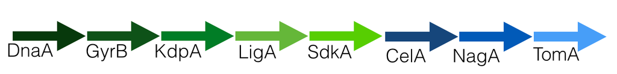

### Housekeeping genes:

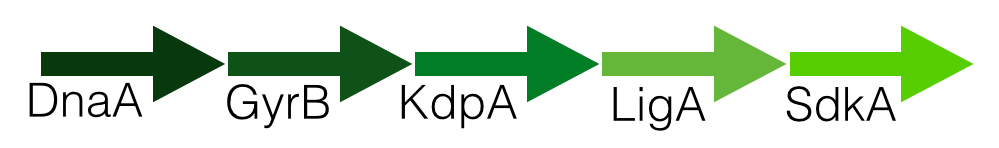

### Virulence genes:

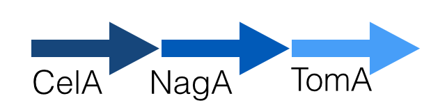